# Final Exam

Vijay Penmetsa

There are five questions (58 total points). Please type in your answers directly in the R Markdown file. After completion, **successfully** knitr it as an html file. Submit **both** the html file and the R Markdown file via Canvas. Please name the R Markdown file in the following format: LastName_FirstName_Final.Rmd, e.g. Zhao_Zifeng_Final.Rmd.

## NYZ Times Dataset (58 points)

NYZ Times is a newspaper publishing company. The company maintains a dataset on their last marketing campaigns for promoting online subscription. For each individual customer, the dataset contains the campaign result (Subscriber = Yes/No) and the corresponding customer characteristics. There are 5,000 individual records in the dataset. It contains 7 variables `Age`, `Experience`, `Income`, `Family`, `AvgAmt`, `Education` and `Subscriber`. The data description is as follows.

- `Age`: Age of the customer (in years)
- `Experience`: Working experience of the customer (in years)
- `Income`: Annual income of the customer ($000)
- `Family`: Family size of the customer
- `AvgAmt`: Average amount of online spending per month by the customer ($00)
- `Education`: Education level of the customer (Bachelor / Master / PhD)
- `Subscriber`: Did the marketing campaign convert the customer into a subscriber? (Yes / No)

To promote online subscription more efficiently and effectively, NYZ Times decides to build several statistical models that can predict the conversion probability of each customer, and thus selectively send advertisement to potential customers that have higher conversion probability.

```r
rm(list=ls())
```

### **Q1 [6 points]** Read in Data and Data Partition

**Q1(a) [2 points]** Let’s correctly read in the data in `NYZ_Times.csv` and name it as `total_data`.

```r
## Write code solution to Q1(a) here
total_data <- read.csv("./NYZ_Times.csv", header=T, stringsAsFactors=T)
```

**Q1(b) [2 points]** What is the conversion rate in the current dataset stored in `total_data`?

```r
## Write code solution to Q1(b) here
nrow(total_data[total_data$Subscriber == 'Yes',]) / nrow(total_data) * 100
```

```
## [1] 9.6
```

Answer:  
Conversion rate is 9.6%.

**Q1(c) [2 points]** Let’s partition the data in `total_data` into training **(60%)** and test data **(40%)** and store them as `R` objects `train_data` and `test_data` respectively. Use random seed **`set.seed(7)`**!

```r
## Write code solution to Q1(c) here
set.seed(7)
total_obs <- dim(total_data)[1]
train_index <- sample(1:total_obs, 0.6*total_obs)
train_data <- total_data[train_index,]
test_data <- total_data[-train_index,]
```

### **Q2 [12 points]** Logistic Regression

**Q2(a) [4 points]** Fit a logistic regression model of the dependent variable `Subscriber` w.r.t. all 6 predictors `Age`, `Experience`, `Income`, `Family`, `AvgAmt`, `Education` using the training data, name it `lm_full`.

```r
## Write code solution to Q2(a) here
lm_full <- glm(Subscriber~Age+Experience+Income+Family+AvgAmt+Education,
               family='binomial', data=train_data)
```

**Q2(b) [2 points]** Examine the estimation result of `lm_full`. Are customers with higher Income more likely to be Subscribers?

```r
## Write code solution to Q2(b) here
summary(lm_full)
```

```
##
## Call:
## glm(formula = Subscriber ~ Age + Experience + Income + Family +
##     AvgAmt + Education, family = "binomial", data = train_data)
##
## Deviance Residuals:
##     Min       1Q   Median       3Q      Max
## -1.9351  -0.2250  -0.0842  -0.0288   4.0634
##
## Coefficients:
##                  Estimate Std. Error z value Pr(>|z|)
## (Intercept)     -12.97864    2.11890  -6.125 9.06e-10 ***
## Age              -0.01368    0.07968  -0.172 0.863667
## Experience        0.02414    0.07949   0.304 0.761431
## Income            0.05815    0.00341  17.055  < 2e-16 ***
## Family            0.63253    0.09355   6.761 1.37e-11 ***
## AvgAmt            0.19438    0.05251   3.702 0.000214 ***
## EducationMaster   3.86864    0.31732  12.192  < 2e-16 ***
## EducationPhD      3.78661    0.31528  12.010  < 2e-16 ***
## ---
## Signif. codes:  0 '***' 0.001 '**' 0.01 '*' 0.05 '.' 0.1 ' ' 1
##
## (Dispersion parameter for binomial family taken to be 1)
##
##     Null deviance: 1968.02  on 2999  degrees of freedom
## Residual deviance:  827.56  on 2992  degrees of freedom
## AIC: 843.56
##
## Number of Fisher Scoring iterations: 7
```

Answer:  
Yes. Customers with higher income are more likely to be subscribers because Income has a positive coefficient.

**Q2(c) [4 points]** Let’s further conduct a backward selection for `lm_full` via BIC using the `step()` function and store the final selected model as `lm_bwd`. Make sure you use the **correct** number for the argument `k` in the `step()` function.

```r
## Write code solution to Q2(c) here
lm_bwd <- step(lm_full, direction = 'backward', k = log(dim(train_data)[1]))
```

```
## Start:  AIC=891.61
## Subscriber ~ Age + Experience + Income + Family + AvgAmt + Education
##
##              Df Deviance     AIC
## - Age         1   827.59  883.64
## - Experience  1   827.66  883.70
## <none>            827.56  891.61
## - AvgAmt      1   841.76  897.80
## - Family      1   878.28  934.32
## - Education   2  1095.44 1143.48
## - Income      1  1357.45 1413.50
##
## Step:  AIC=883.64
## Subscriber ~ Experience + Income + Family + AvgAmt + Education
##
##              Df Deviance     AIC
## - Experience  1   829.32  877.36
## <none>            827.59  883.64
## - AvgAmt      1   841.78  889.82
## - Family      1   878.32  926.36
## - Education   2  1104.54 1144.57
## - Income      1  1360.22 1408.26
##
## Step:  AIC=877.36
## Subscriber ~ Income + Family + AvgAmt + Education
##
##             Df Deviance     AIC
## <none>           829.32  877.36
## - AvgAmt     1   843.14  883.18
## - Family     1   878.95  918.99
## - Education  2  1108.89 1140.92
## - Income     1  1360.30 1400.33
```

**Q2(d) [2 points]** Which variables are removed during the backward selection?

Answer:  
Age and Experience were removed during backward selection.

## **Q3 [8 points]** Generalized Additive Model

**Q3(a) [4 points]** To capture potential nonlinear relationship, we fit a GAM model of the dependent variable `Subscriber` w.r.t. all 6 predictors `Age`, `Experience`, `Income`, `Family`, `AvgAmt`, `Education` using the training data, name it `gam1`. Let’s use splines with **df=4** for all **5** numerical predictors, which include `Age`, `Experience`, `Income`, `Family` and `AvgAmt`.

```r
## Write code solution to Q3(a) here
library(gam)
gam1 <- gam(Subscriber ~
            s(Age, df=4)
            +s(Experience, df=4)
            +s(Income, df=4)
            +s(Family, df=4)
            +s(AvgAmt, df=4)
            +Education,
            family = 'binomial',
            data = train_data)
```

**Q3(b) [2 points]** Plot the estimated splines by `gam1`. For the predictor `Income`, is the relationship monotonic?

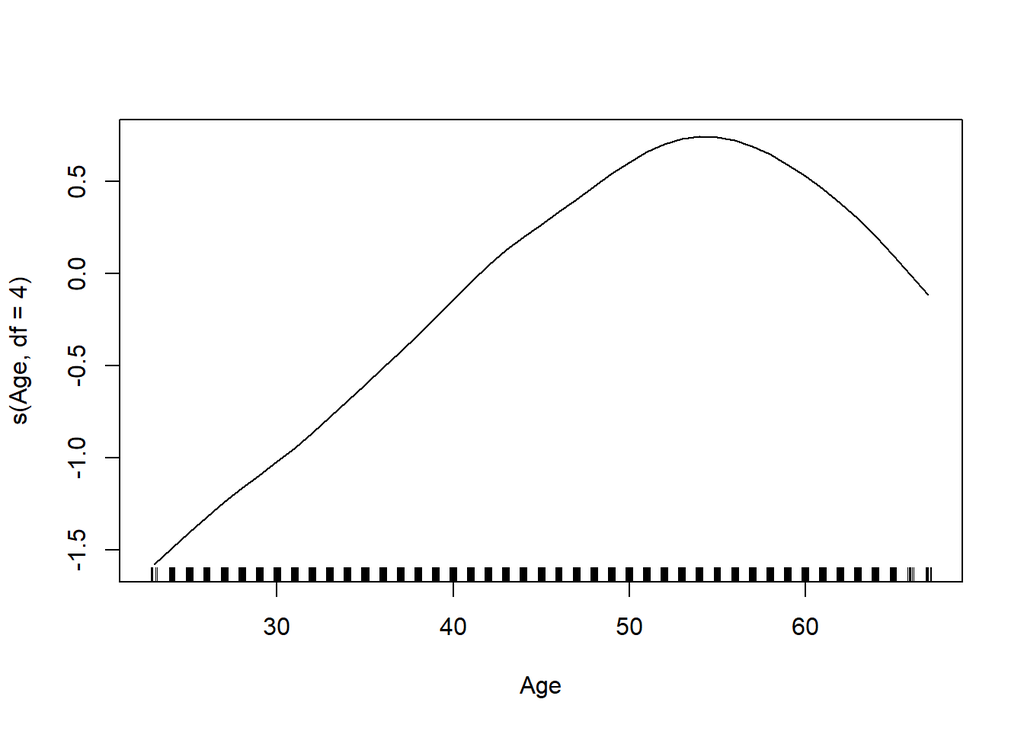

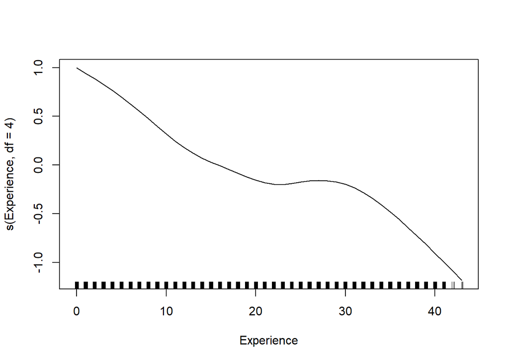

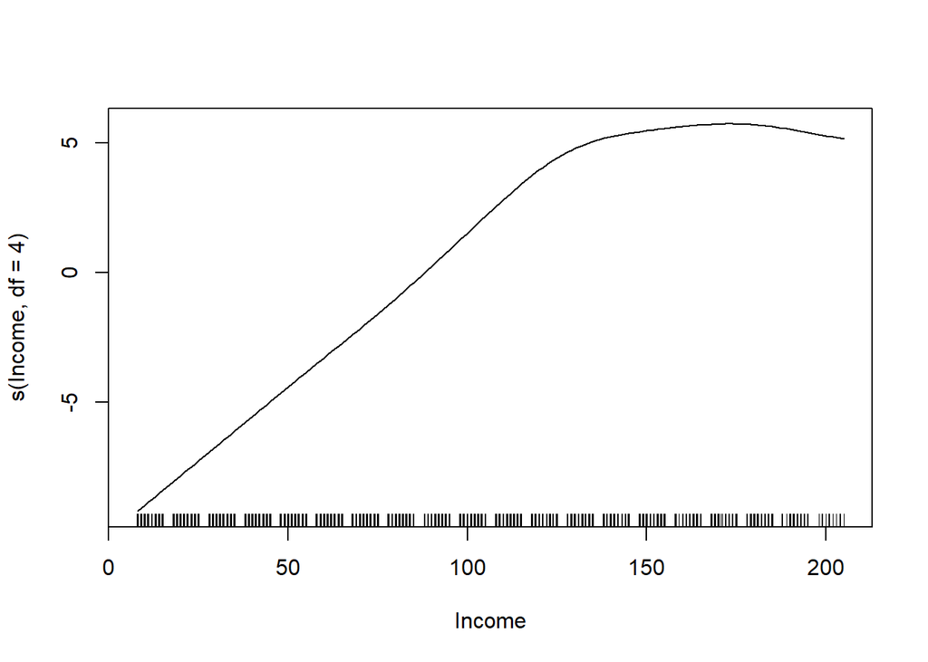

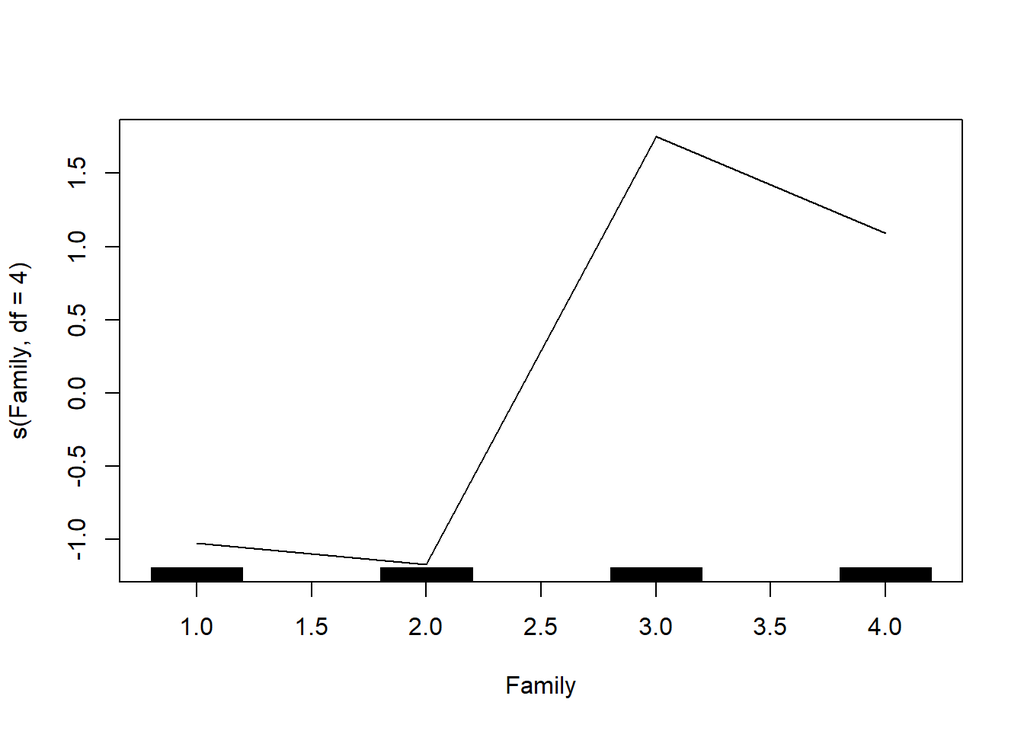

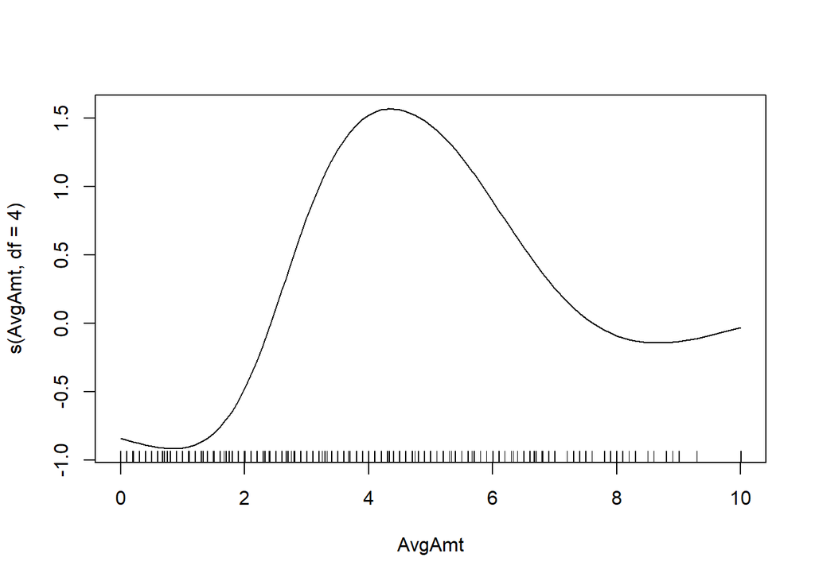

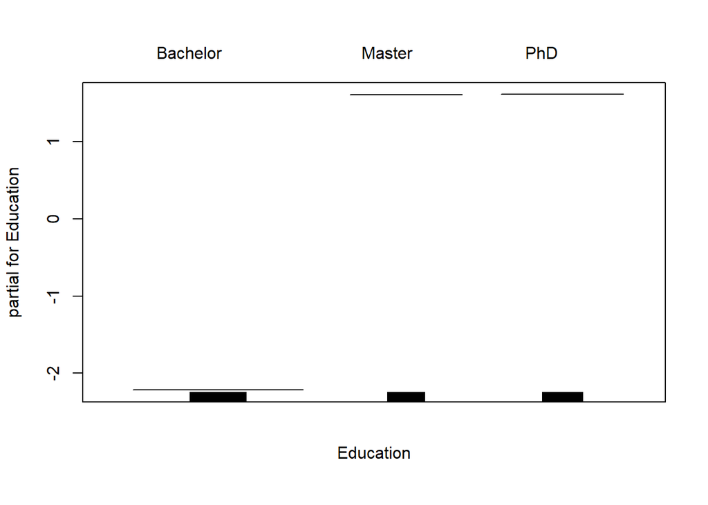

```r
## Write code solution to Q3(b) here
plot(gam1)
```

Answer: No. The relationship for ‘Income’ is non-monotonic.

**Q3(c) [2 points]** Keeping everything else the same, further fit a GAM mobdel but using splines with **df=2** for `Income`, name it `gam2`. Do we have a monotonic relationship for predictor `Income` now?

```r
## Write code solution to Q3(c) here
gam2 <- gam(Subscriber ~
            s(Age, df=4)
            +s(Experience, df=4)
            +s(Income, df=2)
            +s(Family, df=4)
            +s(AvgAmt, df=4)
            +Education,
            family = 'binomial',
            data = train_data)
```

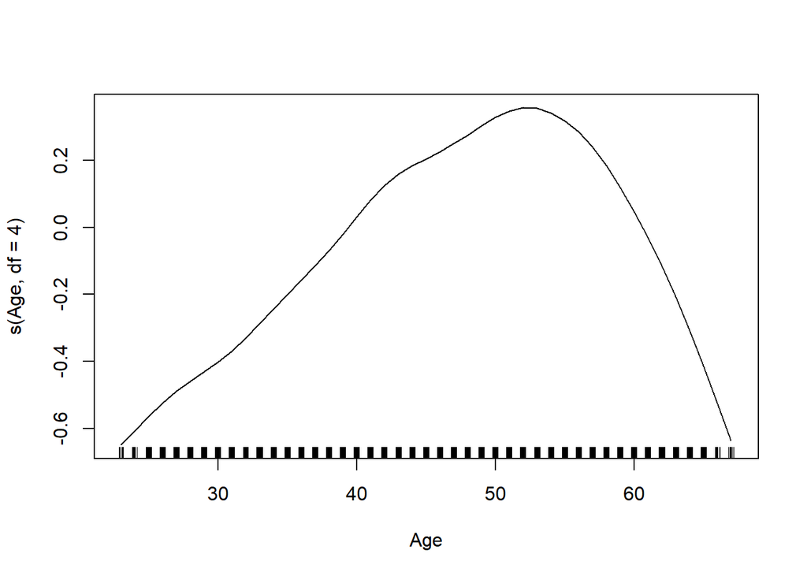

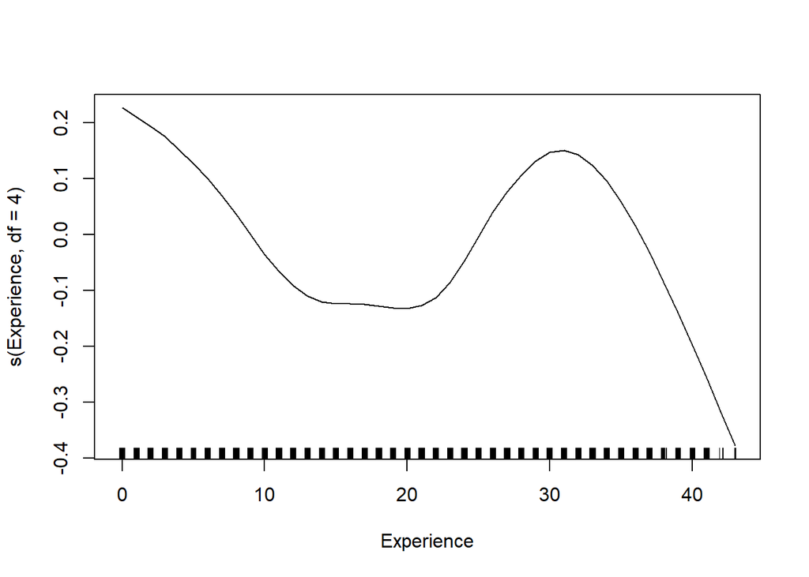

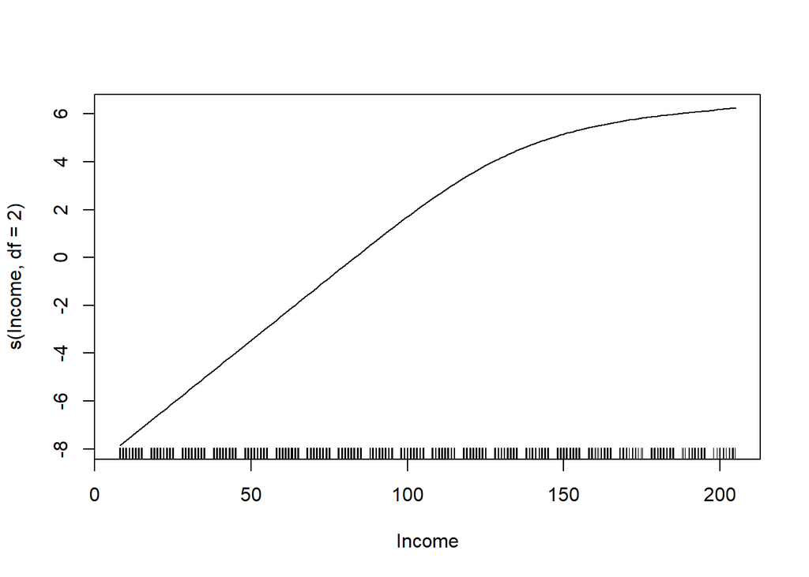

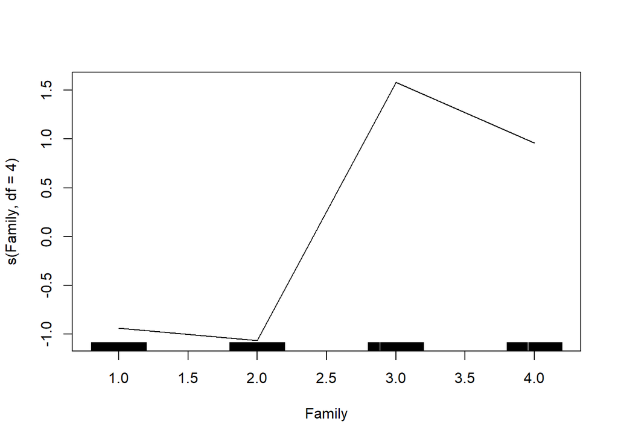

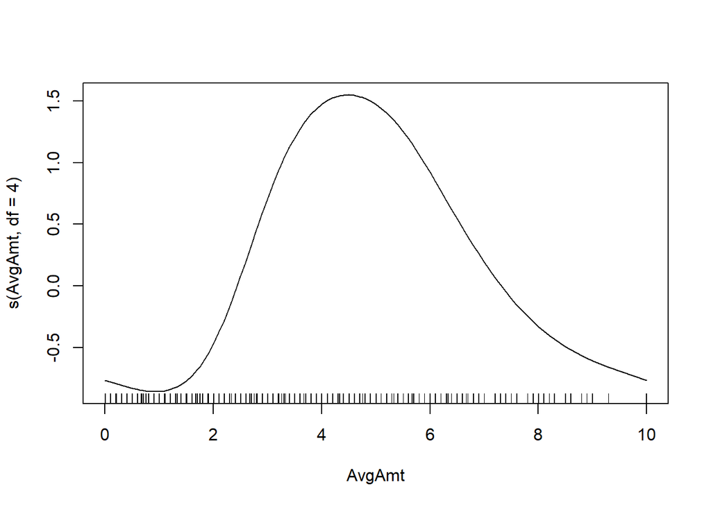

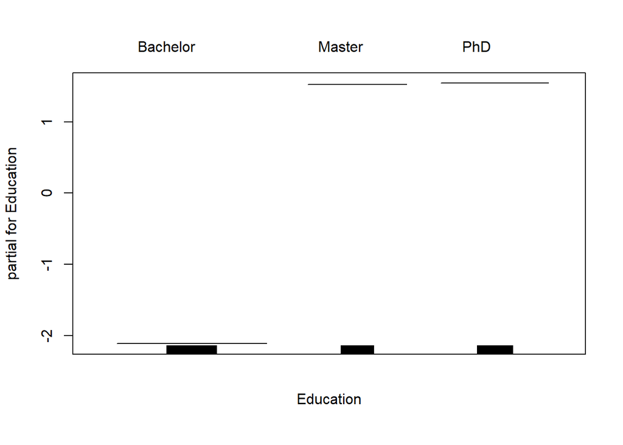

```r
plot(gam2)
```

Answer: Yes. The relationship for predictor ‘Income’ is monotonic when ‘df’ is changed to 2.

### **Q4 [14 points]** Neural Networks

Fit an NN model of the dependent variable `Subscriber` w.r.t. all 6 predictors `Age`, `Experience`, `Income`, `Family`, `AvgAmt`, `Education` using the training data, name it `nn1`. For the architecture of NN, let’s use one hidden layer with **6** hidden units.

**Q4(a) [4 points]** Generate the training dataset that are needed for the estimation of NN using the function `model.matrix()` and store it in `x_train_nn`. In addition, use the `scale()` function to standardize the predictors by centering with mean and scaling with sd.

```r
## Write code solution to Q4(a) here

x_train_nn <- model.matrix(~Age+Experience+Income+Family+AvgAmt+Education,
                           data=train_data)[,-1]

x_mean <- apply(x_train_nn, 2, mean)
x_sd <- apply(x_train_nn, 2, sd)
x_train_nn <- scale(x_train_nn, center=x_mean, scale=x_sd)
```

**Q4(b) [2 points]** Further combine the dependent variable `Subscriber` with the standardized predictors `x_train_nn` generated in Q4(a). Don’t forget to rename the first column of the data frame as `Subscriber`.

```r
## Write code solution to Q4(b) here
x_train_nn <- cbind.data.frame(train_data$Subscriber, x_train_nn)
colnames(x_train_nn)[1] <- 'Subscriber'
```

**Q4(c) [2 points]** Generate the test dataset that are needed for the out-of-sample prediction evaluation of NN using the function `model.matrix` and store it in `x_test_nn`. Use the `scale()` function to standardize the predictors by centering with mean and scaling with sd as in Q4(a).

```r
## Write code solution to Q4(c) here
x_test_nn <- model.matrix(~Age+Experience+Income+Family+AvgAmt+Education,
                          data=test_data)[,-1]

x_test_nn <- scale(x_test_nn, center=x_mean, scale=x_sd)
```

**Q4(d) [6 points]** Fit an NN that has one hidden layers with **6** hidden units and name it `nn1`. Make sure to use random seed **`set.seed(7)`**!

```r
## Write code solution to Q4(d) here
library(neuralnet)
set.seed(7)
nn1 <- neuralnet(Subscriber=='Yes'~.,
                 data=x_train_nn, hidden=c(6), linear.output=F)
```

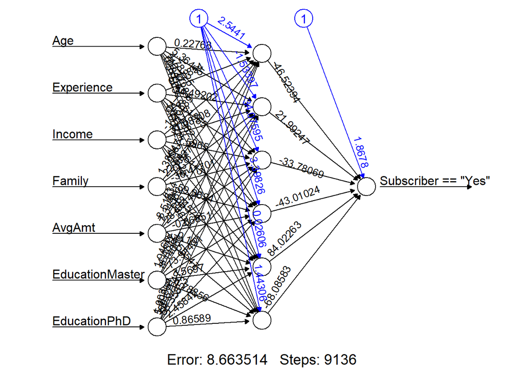

```r
plot(nn1, rep='best')
```

### **Q5 [18 points]** Model Evaluation (Prediction)

**Q5(a) [4 points]** Use `lm_full`, `gam1` and `nn1` to generate probability predictions on the test data and store the prediction in `lm_full_pred`, `gam1_pred` and `nn1_pred` respectively.

```r
## Write code solution to Q5(a) here
lm_full_pred <- predict(lm_full, newdata=test_data, type = 'response')
gam1_pred <- predict(gam1, newdata=test_data, type = 'response')
nn1_pred <- predict(nn1, newdata=x_test_nn, type = 'response')[,1]
```

**Q5(b) [2 points]** What are the predicted conversion probability of the **fifth** customer in the test data by `lm_full`, `gam1` and `nn1`, respectively?

```r
## Write code solution to Q5(b) here
lm_full_pred[5] * 100
```

```
##        7
## 3.106382
```

```r
gam1_pred[5] * 100
```

```
##         7
## 0.1688447
```

```r
nn1_pred[5] * 100
```

```
##            7
## 1.294744e-19
```

Answer:  
The predicted conversion probability of the fifth customer in test data is:  
lm_full: 3.106382 %  
gam1: 0.1688447 %  
nn1: 0% (1.294744e-19 %)

**Q5(c) [2 points]** Use the `R` package `caret` to evaluate the prediction performance of `lm_full`, `gam1` and `nn1` on the test data. What are the sensitivity of `lm_full`, `gam1` and `nn1`?

```r
## Write code solution to Q5(c) here
library(caret)
lm_full_acc <- confusionMatrix(factor(ifelse(lm_full_pred>0.5, 'Yes', 'No')), test_data$Subscriber,
                               positive='Yes')

gam1_acc <- confusionMatrix(factor(ifelse(gam1_pred>0.5, 'Yes', 'No')), test_data$Subscriber,
                           positive='Yes')

nn1_acc <- confusionMatrix(factor(ifelse(nn1_pred>0.5, 'Yes', 'No')), test_data$Subscriber,
                           positive='Yes')
```

```r
lm_full_acc
```

```
## Confusion Matrix and Statistics
##
##           Reference
## Prediction   No  Yes
##        No  1807   68
##        Yes   17  108
##
##                Accuracy : 0.9575
##                  95% CI : (0.9477, 0.9659)
##     No Information Rate : 0.912
##     P-Value [Acc > NIR] : 1.933e-15
##
##                   Kappa : 0.6953
##
##  Mcnemar's Test P-Value : 5.852e-08
##
##             Sensitivity : 0.6136
##             Specificity : 0.9907
##          Pos Pred Value : 0.8640
##          Neg Pred Value : 0.9637
##              Prevalence : 0.0880
##          Detection Rate : 0.0540
##    Detection Prevalence : 0.0625
##       Balanced Accuracy : 0.8022
##
##        'Positive' Class : Yes
##
```

```r
gam1_acc
```

```
## Confusion Matrix and Statistics
##
##           Reference
## Prediction   No  Yes
##        No  1813   37
##        Yes   11  139
##
##                Accuracy : 0.976
##                  95% CI : (0.9683, 0.9823)
##     No Information Rate : 0.912
##     P-Value [Acc > NIR] : < 2.2e-16
##
##                   Kappa : 0.8398
##
##  Mcnemar's Test P-Value : 0.000308
##
##             Sensitivity : 0.7898
##             Specificity : 0.9940
##          Pos Pred Value : 0.9267
##          Neg Pred Value : 0.9800
##              Prevalence : 0.0880
##          Detection Rate : 0.0695
##    Detection Prevalence : 0.0750
##       Balanced Accuracy : 0.8919
##
##        'Positive' Class : Yes
##
```

```r
nn1_acc
```

```
## Confusion Matrix and Statistics
##
##           Reference
## Prediction   No  Yes
##        No  1818   18
##        Yes    6  158
##
##                Accuracy : 0.988
##                  95% CI : (0.9822, 0.9923)
##     No Information Rate : 0.912
##     P-Value [Acc > NIR] : < 2e-16
##
##                   Kappa : 0.9229
##
##  Mcnemar's Test P-Value : 0.02474
##
##             Sensitivity : 0.8977
##             Specificity : 0.9967
##          Pos Pred Value : 0.9634
##          Neg Pred Value : 0.9902
##              Prevalence : 0.0880
##          Detection Rate : 0.0790
##    Detection Prevalence : 0.0820
##       Balanced Accuracy : 0.9472
##
##        'Positive' Class : Yes
##
```

Answer:  
Sensitivity values  
lm_full: 0.6136  
gam1: 0.7898  
nn1: 0.8977

**Q5(d) [4 points]** Based on the result in Q5(c), fill out the confusion matrix for `gam` and `nn1` on the written exam.  
Answer: On Paper

**Q5(e) [2 points]** Further generate a lift chart to compare the prediction performance of `lm_full`, `gam1` and `nn1`. To make the lift chart look nice, do **NOT** use the `cuts` argument.

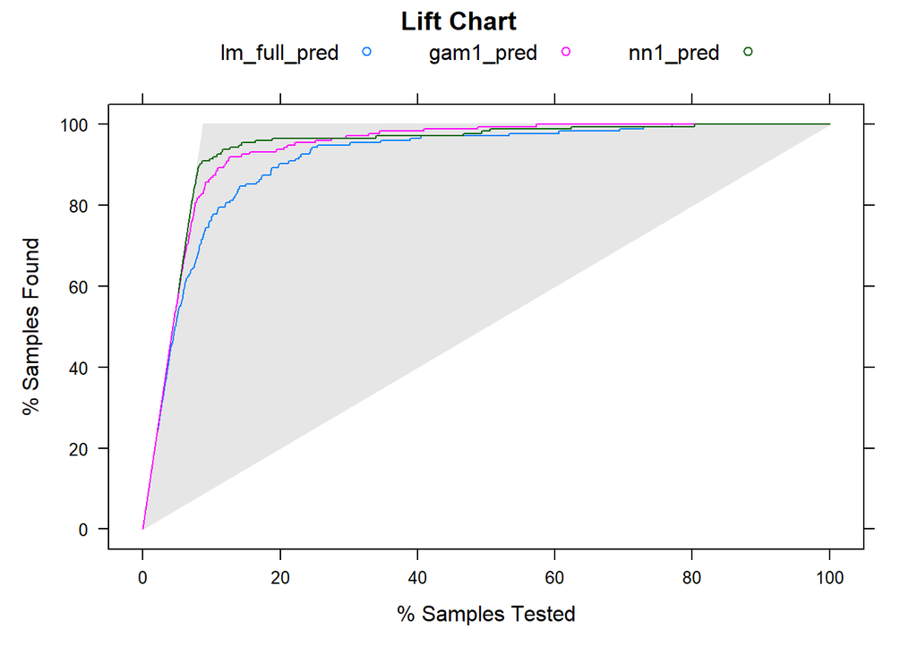

```r
## Write code solution to Q5(e) here
lift_chart <- lift(test_data$Subscriber~lm_full_pred+gam1_pred+nn1_pred, class='Yes')
xyplot(lift_chart, auto.key=list(columns=3), main='Lift Chart')
```

**Q5(g) [2 points]** Take `lm_full` for example. If we want to capture more than 80% of all potential customers (i.e. customers who will become subscriber), what should be our minimum marketing budget? In other words, what is the percentage of customers we should reach out to? (The answer does not need to be exact, it only needs to be approximately correct.)